# ConsortiumStuff

## Confirmation of Results

As an example confirmation, https://www.snpedia.com/index.php/Rs1042725 found nature SNP rs1042725 is associated with height (P = 4E-8) in a study involving over 20,000 individuals.rs6060369 was also confirmed.

Let’s see how many SNPS per trait:

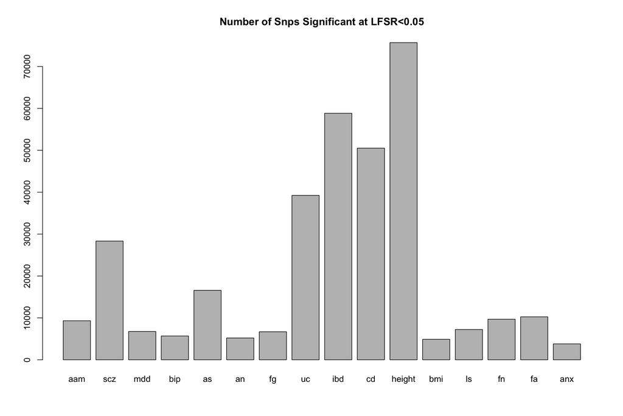

```r
barplot(colSums(lfsr.mash<0.05),main="Number of Snps Significant at LFSR<0.05")
```

Let’s generate the top SNPs per trait:

```r
colnames(lfsr.mash)=colnames(z.stat)
rownames(lfsr.mash)=rownames(z.stat)
data.frame(apply(lfsr.mash,2,function(x){(rownames(lfsr.mash)[order(x,decreasing=F)][1:10])}))
```

```
##    reprogen_aam_beta pgc_scz_beta pgc_mdd_beta pgc_bip_beta pgc_as_beta
## 1          rs4976665   rs10484439   rs10182181    rs4382763   rs1269195
## 2         rs11739147   rs13198716    rs6752378   rs12075079   rs9375450
## 3           rs734518    rs7746199    rs6545814   rs10489290   rs2184968
## 4         rs17355209   rs13195040    rs6721750    rs4072117   rs2152876
## 5          rs1472920   rs10484399    rs2384058   rs12402454   rs4559102
## 6          rs2962842   rs17749927   rs13407913   rs10489289   rs4549631
## 7          rs2940521   rs17750424     rs713587   rs16844255   rs7738836
## 8          rs2860534   rs17693963    rs7567997   rs12911223   rs1538956
## 9          rs3923879   rs13199772    rs2033654    rs7296288   rs1340952
## 10         rs7718874   rs13197574   rs10198275    rs2135551   rs3861455
##    pgc_an_beta magic_fg_beta ibdgenetics_uc_beta ibdgenetics_ibd_beta
## 1     rs724016     rs2908282           rs3812558            rs6556412
## 2    rs9846396    rs10830961          rs10753575            rs3812558
## 3   rs12969709      rs477224           rs6426833            rs4487900
```

[output cut: 29 more lines]

```r
write.table(data.frame(apply(lfsr.mash,2,function(x){(rownames(lfsr.mash)[order(x,decreasing=F)][1:10])}))
,"top10pertrait.txt")
```

Let’s show how this integrates with the GTEX results:

```r
topten=read.table("top10pertrait.txt",header=T,stringsAsFactors = F)
topten[1,"scz"]
```

[output not shown]

Is an eQTL in Brain, Frontal Cortex [as shown here in the GteX browser](http://www.gtexportal.org/home/eqtls/bySnp?snpId=rs10484439&tissueName=Brain_Frontal_Cortex_BA9) representing a possible link to disease.

Now, we’d like to add pairwise sharing by magnitude and sign:

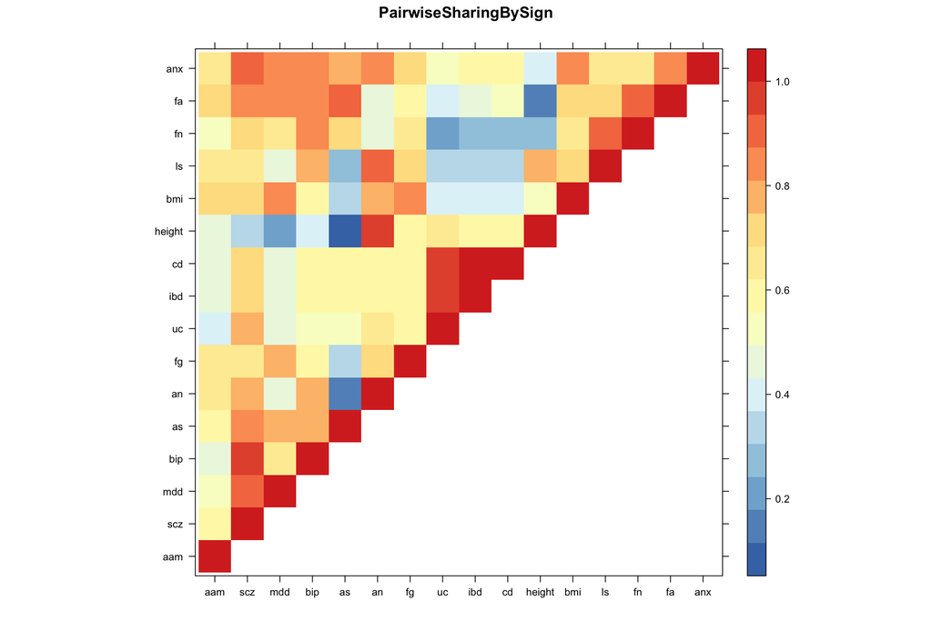

```r
library("mashr")
se.matched=as.matrix(read.table("../Data/se.matched.txt"))
pm.mash.beta=post.means*se.matched
colnames(pm.mash.beta)=names
lfsr.mash.sig=lfsr.mash[rowSums(lfsr.mash<0.05)>0,]##only 137,223 are significant in at least one subgroup
pm.mash.sig=pm.mash.beta[rowSums(lfsr.mash<0.05)>0,]

signheatmap=compute.sharing.by.sign(lfsr.mash = lfsr.mash.sig,thresh = 0.05,pm.mash.beta = pm.mash.sig)
signheatmap[lower.tri(signheatmap)] <- NA
magheatmap=compute.mag.by.sharing(lfsr.mash = lfsr.mash.sig,thresh = 0.05,pm.mash.beta = pm.mash.sig)
magheatmap[lower.tri(magheatmap)] <- NA


library('colorRamps')
library('corrplot')
library(gplots)
library(ggplot2)

# class(signheatmap)
#
#
# heatmap.2(signheatmap,Rowv=FALSE,Colv=FALSE,
#           symm=TRUE,dendrogram="none",density="none",trace="none",#col=redblue,
#           col=blue2green,main=paste0("Pairwise Sharing by Sign"),
#           cexRow=0.6,cexCol=0.5,cex.main=0.5,breaks=seq(0.7,1,0.01))


library('lattice')

clrs <- colorRampPalette(rev(c("#D73027","#FC8D59","#FEE090","#FFFFBF",
                            "#E0F3F8","#91BFDB","#4575B4")))
#clrs[63:64] <- "darkviolet"
lat=signheatmap
lat[lower.tri(lat)] <- NA


print(levelplot(lat,#col.regions = colorRampPalette(c('dark red','white','dark blue'))),
      col.regions=clrs,
                xlab = "",ylab = "",colorkey = TRUE,main="PairwiseSharingBySign"))
```

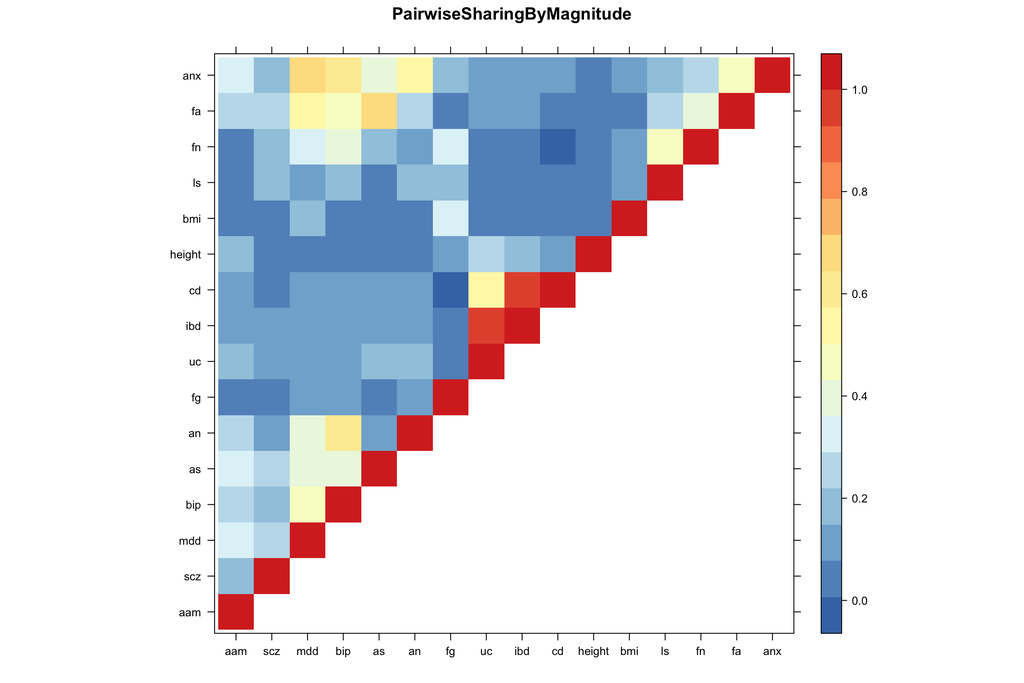

```r
clrs <- colorRampPalette(rev(c("#D73027","#FC8D59","#FEE090","#FFFFBF",
                            "#E0F3F8","#91BFDB","#4575B4")))
#clrs[63:64] <- "darkviolet"
lat=magheatmap
lat[lower.tri(lat)] <- NA

print(levelplot(lat,#col.regions = colorRampPalette(c('dark red','white','dark blue'))),
      col.regions=clrs,
                xlab = "",ylab = "",colorkey = TRUE,main="PairwiseSharingByMagnitude"))
```

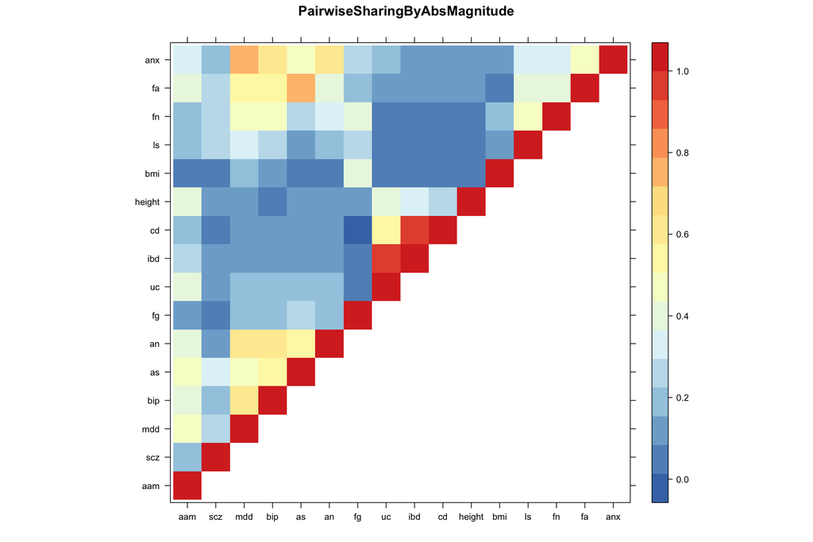

```r
# heatmap.2(magheatmap,Rowv=FALSE,Colv=FALSE,
#           symm=TRUE,dendrogram="none",density="none",trace="none",#col=redblue,
#           col=blue2green,main=paste0("Pairwise Sharing by Magnitude"),
#           cexRow=0.6,cexCol=2,cex.main=0.5,#breaks=seq(0.35,1,0.01),
#           labCol=NA)

library('lattice')

clrs <- colorRampPalette(rev(c("#D73027","#FC8D59","#FEE090","#FFFFBF","#E0F3F8","#91BFDB","#4575B4")))(64)

#clrs=colorRampPalette(c('dark red','white','dark blue'))
#clrs[63:64] <- "darkviolet"

absmagheatmap=compute.mag.by.sharing(lfsr.mash = lfsr.mash.sig,thresh = 0.05,pm.mash.beta = abs(pm.mash.sig))
absmagheatmap[lower.tri(absmagheatmap)] <- NA
lat=absmagheatmap
lat[lower.tri(lat)] <- NA


print(levelplot(lat,col.regions = clrs,main="PairwiseSharingByAbsMagnitude",#colorRampPalette(c('dark red','white','dark blue'))),
                xlab = "",ylab = "",colorkey = TRUE))
```

Now, let’s look at sharing my asbolute value of magntiude:

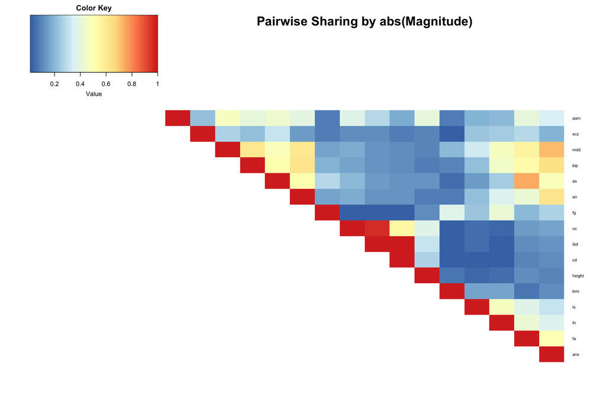

```r
# heatmap.2(signheatmap,Rowv=FALSE,Colv=FALSE,
#           symm=TRUE,dendrogram="none",density="none",trace="none",#col=redblue,
#           #col=blue2green,
#           col=colorRampPalette(c('dark red','white','dark blue')),
# main=paste0("Pairwise Sharing by Sign"),
#           cexRow=0.6,cexCol=0.5,cex.main=0.5)
# #,breaks=seq(0.7,1,0.01))
#
# heatmap.2(1-signheatmap,Rowv=FALSE,Colv=FALSE,
#           symm=TRUE,dendrogram="none",density="none",trace="none",#col=redblue,
#           col=colorRampPalette(c('dark red','white','dark blue')),
#           #col=blue2green,
#           main=paste0("Pairwise Sharing by Opposite Sign"),
#           cexRow=0.6,cexCol=0.5,cex.main=0.5)
#,breaks=seq(0.7,1,0.01))



absmagheatmap=compute.mag.by.sharing(lfsr.mash = lfsr.mash.sig,thresh = 0.05,pm.mash.beta = abs(pm.mash.sig))
absmagheatmap[lower.tri(absmagheatmap)] <- NA
heatmap.2(absmagheatmap,Rowv=FALSE,Colv=FALSE,
          symm=TRUE,dendrogram="none",density="none",trace="none",#col=redblue,
          #col=blue2green,
          col=clrs,
          main=paste0("Pairwise Sharing by abs(Magnitude)"),
          cexRow=0.6,cexCol=2,cex.main=0.5,#breaks=seq(0.35,1,0.01),
          labCol=NA)
```

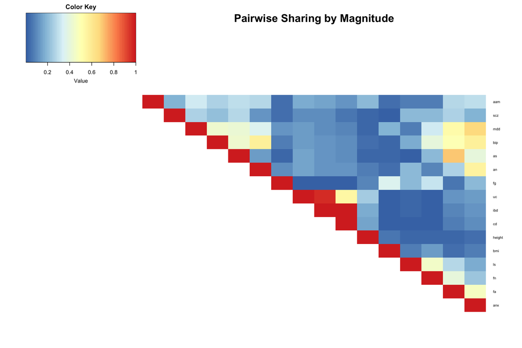

```r
heatmap.2(magheatmap,Rowv=FALSE,Colv=FALSE,
          symm=TRUE,dendrogram="none",density="none",trace="none",#col=redblue,
          #col=blue2green,
          col=clrs,main=paste0("Pairwise Sharing by Magnitude"),
          cexRow=0.6,cexCol=2,cex.main=0.5,#breaks=seq(0.35,1,0.01),
          labCol=NA)
```